# Tips_for_production slides

### How to win at kaggle

1. Get good validation.
2. Iterate quickly.
3. Make things fast to not get distracted.
4. Automate things (even the small things) to not lose mental energy.

### Bringing Machine Learning in Production

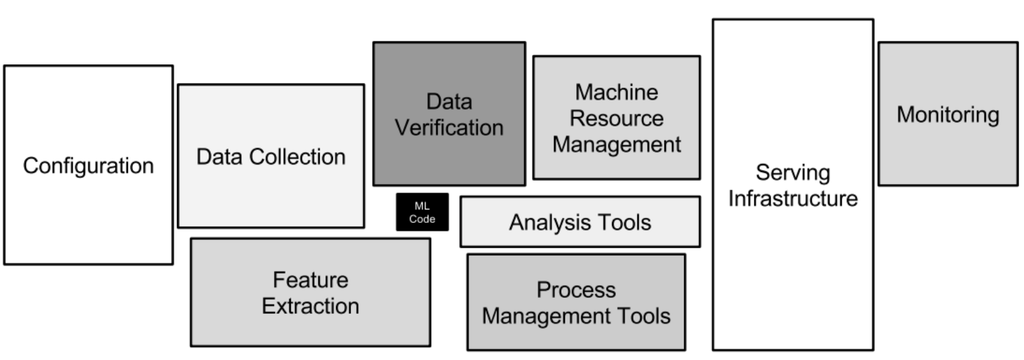

[Hidden Technical Debt in Machine Learning Systems](https://proceedings.neurips.cc/paper/2015/file/86df7dcfd896fcaf2674f757a2463eba-Paper.pdf)

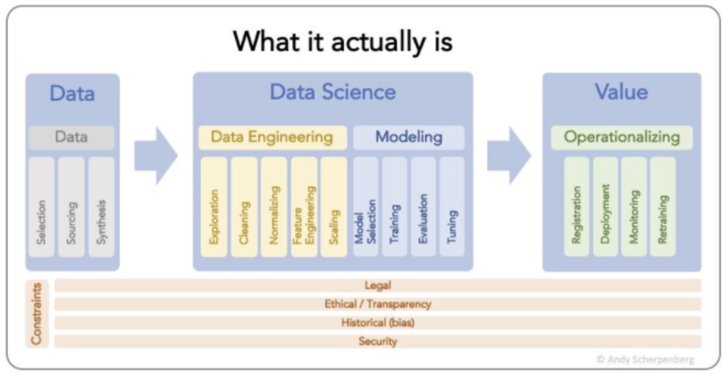

## Where is DS going?

- Data Governance
  1. personal and other sensitive data
  2. who is allowed to see the data
  3. how long is data kept
  4. is the data kept secure?
  5. documentation of data (source, meaning, preprocessing, etc.)
  6. what decisions are taken based on ML models?
- Explainability, Compliance, Transparency and Fairness
  1. Why have I not received the loan? Why am I suspicious?
  2. Is there a bias in my data? Discriminatory decisions?
- Auditing Machine Learning Models
  1. as for risk-assessment in the banking industry: regulations for ML?
  2. Deloitte, Ernst & Young, KPMG and PwC?

[apple card](https://www.bbc.com/news/business-50365609)

[On the Dangers of Stochastic Parrots: Can Language Models Be Too Big?](https://dl.acm.org/doi/pdf/10.1145/3442188.3445922)  
"...investing resources into curating and carefully documenting datasets rather than ingesting everything on the web,..." [What Really Happened When Google Ousted Timnit Gebru](https://www.wired.com/story/google-timnit-gebru-ai-what-really-happened/)

[BLOOM](https://www.nature.com/articles/d41586-022-01705-z):  
"We wanted to make sure people with proximity to the data, their country, the language they speak, had a hand in choosing what language came into the model’s training"  
"The collaboration also attempted to reduce the usual over-representation of porn sites"

[figure not shown]